# Q3-DeltaHedging(Real-World)

Bai Haoyu G1900411H, Fang Yuan G1900299H, Hsiung Yi G1900278D, Kevin Chen G1900380F, Liu Nuozhou G1800068F

27/10/2019

##### We select Amazon (AMZN) to be our target stock. In the past, Amazon has never paid dividends, so q is 0 throughout the project

### Construct the xts object

```r
AMZNXTS <- xts(x = AMZN[, -1, drop = F],
                  order.by = as.Date(AMZN$Date, format = "%d/%m/%Y"))
```

### Initial Setup

##### The operation dates(first day of each 30-day trading period) are stored in a list with length 12:

##### “2018-08-31” “2018-10-01” “2018-10-31” “2018-11-30” “2018-12-31” “2019-01-30” “2019-03-01” “2019-04-01” “2019-05-01” “2019-05-31” “2019-07-01” “2019-07-31”. The last 30-day period is from “2019-07-31 to 2019-08-30”.

##### Some of the durations are not extactly 30 days because the last day of the 30-day holding period may not be a trading day. In such case, we hold one/multiple days more until the next trading day

```r
# quantity to hold
Quantity <- 100

# risk free rates
RF <- 0.8/100

# create a list of trading dates
Trading_Date <- index(AMZNXTS)
checking_dates <- as.numeric(Trading_Date)
startdate <- as.numeric(as.Date("2018-08-31"))
operationdates <- c(startdate)
for (i in 1:12)
{
  newdate <- startdate + 30
  while (!(newdate %in% checking_dates))
  {
    newdate <- newdate+1
  }
  operationdates <- c(operationdates, newdate)
  startdate <- newdate
}
operationdates <- as.Date(operationdates)
trade_dates <- which(checking_dates %in% operationdates[-length(operationdates)])
trade_dates2 <- which(checking_dates %in% operationdates)

# create a dataframe for later calculation
AMZNDF <- tibble(date = Trading_Date)
AMZNDF$Close <- coredata(AMZNXTS[, "Close"])
AMZNDF$IV30 <- coredata(AMZNXTS[, "VXAZNCLS"])

# create a dataframe for result storage
AMZNDFOutput <- AMZNDF[trade_dates, ] %>%
  mutate(Total_PnL = 0, Option_PnL = 0, Stock_PnL = 0, MaxDrawdown = 0, SharpeRatio = 0)
```

### Calculation for each period

```r
# Round 2 analysis for Guessing Strike level
Strikes <- c(0)
deltas <- c(0)

# Realized volatility and Implied volatility
RealizedVol <- c(0)
ImpliedVol <- c(0)
Dates <- c(0)

for (i in 1:12){
  # initialize the dates af a 30-day trading period
  start_date <- as.numeric(AMZNDF[trade_dates2[i],1])
  end_date <- as.numeric(AMZNDF[trade_dates2[i+1],1])
  start_price <- as.numeric(AMZNDF[trade_dates2[i],2])
  start_vol <- as.numeric(AMZNDF[trade_dates2[i],3])

  # data for calculation of this period
  tempDF <- tibble(date = Trading_Date[as.numeric(Trading_Date)<end_date & as.numeric(Trading_Date)>=start_date]) %>%
    rowwise() %>%
    mutate(Close = as.numeric(AMZNXTS[date,"Close"])) %>%
    ungroup()

  # record volatilitis
  Dates <- c(Dates, as.Date(start_date))
  ImpliedVol <- c(ImpliedVol, start_vol)
  price <- log(tempDF$Close)
  ret <- log(dplyr::lag(price)) - log(price)
  p <- price[-length(price)]
  p2 <- price[-1]
  ret <- p2-p
  vol <- sd(ret) * sqrt(250) * 100
  RealizedVol <- c(RealizedVol, vol)

  # Round 2 analysis - guess the 25% delta strike price
  initialguess <- start_price * 5
  goal <- GBSGreeks("delta", TypeFlag = "c",
                                   S = start_price,
                                   X = initialguess,
                                   Time = (end_date - as.numeric(start_date))/365,
                                   r = RF,
                                   b = 0,
                                   sigma = start_vol/100)

  if(goal < 0.25)
  {
    while(goal < 0.245)
   {
    initialguess <- initialguess - 1
    goal <- GBSGreeks("delta", TypeFlag = "c",
                                   S = start_price,
                                   X = initialguess,
                                   Time = (end_date - as.numeric(start_date))/365,
                                   r = RF,
                                   b = 0,
                                   sigma = start_vol/100)
   }
  }
  else
  {
    while(goal > 0.255)
   {
    initialguess <- initialguess + 1
    goal <- GBSGreeks("delta", TypeFlag = "c",
                                   S = start_price,
                                   X = initialguess,
                                   Time = (end_date - as.numeric(start_date))/365,
                                   r = RF,
                                   b = 0,
                                   sigma = start_vol/100)
   }
  }

  d1 <- GBSGreeks("delta", TypeFlag = "c",
                                   S = start_price,
                                   X = initialguess - 1,
                                   Time = (end_date - as.numeric(start_date))/365,
                                   r = RF,
                                   b = 0,
                                   sigma = start_vol/100)
  d2 <- GBSGreeks("delta", TypeFlag = "c",
                                   S = start_price,
                                   X = initialguess + 1,
                                   Time = (end_date - as.numeric(start_date))/365,
                                   r = RF,
                                   b = 0,
                                   sigma = start_vol/100)

  if(abs(d1-0.25) < abs(goal-0.25))
  {
    if(abs(d1-0.25) < abs(d2-0.25))
    {
      add <- initialguess - 1
      objective <- d1
    }
    if(abs(d1-0.25) > abs(d2-0.25))
    {
      add <- initialguess + 1
      objective <- d2
    }
  }
  if(abs(d1-0.25) > abs(goal-0.25))
  {
    if(abs(goal-0.25) < abs(d2-0.25))
    {
      add <- initialguess
      objective <- goal
    }
    if(abs(goal-0.25) > abs(d2-0.25))
    {
      add <- initialguess + 1
      objective <- d2
    }
  }

  Strikes <- c(Strikes, add)
  deltas <- c(deltas, objective)

  # calculation
  AMZNDF2 <- rowwise(tempDF) %>%
    #1
    mutate(premium = Quantity*GBSOption(TypeFlag = "c",
                               S = Close,
                               X = start_price,
                               Time = (end_date - as.numeric(date))/365,
                               r = RF,
                               b = 0,
                               sigma = start_vol/100)@price) %>%
    ungroup() %>%
    #2
    mutate(Option_DoD_PnL = ifelse(as.numeric(date) == start_date,
                                   0,
                                   premium - dplyr::lag(premium))) %>%
    rowwise() %>%
    #3
    mutate(delta_hedge = Quantity*(-1)*GBSGreeks("delta", TypeFlag = "c",
                                   S = Close,
                                   X = start_price,
                                   Time = (end_date - as.numeric(date))/365,
                                   r = RF,
                                   b = 0,
                                   sigma = start_vol/100)) %>%
    ungroup() %>%
    #4
    mutate(Hedging_DoD_PnL = ifelse(as.numeric(date) == start_date,
                                    0,
                                    dplyr::lag(delta_hedge)*(Close - dplyr::lag(Close)))) %>%
    rowwise() %>%
    #5
    mutate(DoD_PnL = Option_DoD_PnL + Hedging_DoD_PnL,
           Time_to_Expiry = end_date - as.numeric(date),
           Cost_of_Hedging = Close*delta_hedge) %>%

    ungroup() %>%
    #6
    mutate(Cum_PnL = cumsum(DoD_PnL),
           Option_Cum_PnL = cumsum(Option_DoD_PnL),
           Stock_Cum_PnL = cumsum(Hedging_DoD_PnL))

  # store in the AMZNDFOutput dataframe for back-testing
  AMZNDFOutput[i,4] <- tail(AMZNDF2$Cum_PnL, n = 1)

  AMZNDFOutput[i,5] <- tail(AMZNDF2$Option_Cum_PnL, n = 1)

  AMZNDFOutput[i,6] <- AMZNDF2$Stock_Cum_PnL[nrow(AMZNDF2)]

  AMZNDFOutput[i,7] <- max(max(AMZNDF2$Cum_PnL) - min(AMZNDF2$Cum_PnL))

  AMZNDFOutput[i,8] <- (mean(AMZNDF2$DoD_PnL)-RF*(AMZNDF2$premium[1]+max(AMZNDF2$Cost_of_Hedging)))/stdev(AMZNDF2$DoD_PnL)
}
```

### Round 2 Analysis - Guessing K

```r
Strikes <- Strikes[-1]
deltas <- deltas[-1]
cat("The Strike prices for ~25% Delta are:")
## The Strike prices for ~25% Delta are:
cat(Strikes)
## 2114.55 2145.8 1743.05 1831.85 1667.85 1815.15 1756.65 1927.95 1999.6 1888.35 2026.95 1964.9
cat("The corresponding deltas are:")
## The corresponding deltas are:
cat(deltas)
## 0.2491445 0.2473383 0.2473039 0.2480723 0.2465935 0.2476754 0.2486764 0.247698 0.2491508 0.2472676 0.2474791 0.2476783
```

### One-trade analysis

##### The analyzed period is the last 30-day trading period, from “2019-07-31 to 2019-08-30”

###1. Final PnL/Option Final PnL/Stock Final PnL

```r
cat(paste0("Final PnL: $", sprintf("%.2f",AMZNDF2$Cum_PnL[nrow(AMZNDF2)]), ".\n",
           "Option PnL: $", sprintf("%.2f",AMZNDF2$Option_Cum_PnL[nrow(AMZNDF2)]), ".\n",
           "Stock PnL: $", sprintf("%.2f",AMZNDF2$Stock_Cum_PnL[nrow(AMZNDF2)]), ".\n" ))
## Final PnL: $772.01.
## Option PnL: $-5315.83.
## Stock PnL: $6087.83.
```

### 2. Max Drawdown:

```r
cat(paste0("MaxDrawdown: $", sprintf("%.2f",max(max(AMZNDF2$Cum_PnL) - min(AMZNDF2$Cum_PnL))), ".\n" ))
## MaxDrawdown: $1001.62.
```

### 3. Sharpe Ratio:

```r
cat(paste0("Sharpe Ratio: ", sprintf("%.3f",(mean(AMZNDF2$DoD_PnL)-RF*(AMZNDF2$premium[1]+max(AMZNDF2$Cost_of_Hedging)))/stdev(AMZNDF2$DoD_PnL)), ".\n" ))
## Sharpe Ratio: -0.037.
```

### 4. Daily PnL/Cumulative PnL vs. Time to Expiry

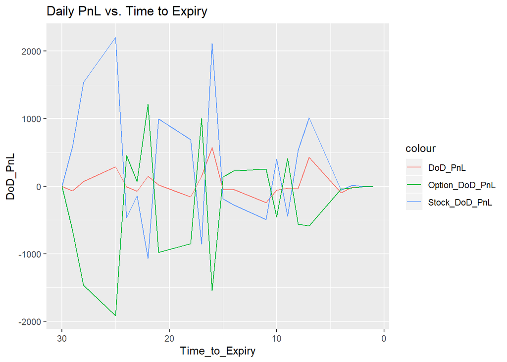

```r
ggplot(AMZNDF2) +
  geom_line(aes(Time_to_Expiry,DoD_PnL, color = "DoD_PnL")) +
  geom_line(aes(Time_to_Expiry,Hedging_DoD_PnL, color = "Stock_DoD_PnL")) +
  geom_line(aes(Time_to_Expiry,Option_DoD_PnL, color = "Option_DoD_PnL")) +
  ggtitle("Daily PnL vs. Time to Expiry") +
  scale_x_reverse()
```

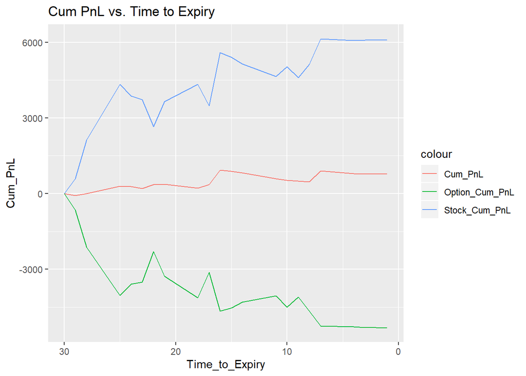

```r
ggplot(AMZNDF2) +
  geom_line(aes(Time_to_Expiry,Cum_PnL, color = "Cum_PnL")) +
  geom_line(aes(Time_to_Expiry,Stock_Cum_PnL, color = "Stock_Cum_PnL")) +
  geom_line(aes(Time_to_Expiry,Option_Cum_PnL, color = "Option_Cum_PnL")) +
  ggtitle("Cum PnL vs. Time to Expiry")+
  scale_x_reverse()
```

### 1. Distribution of Final PnL

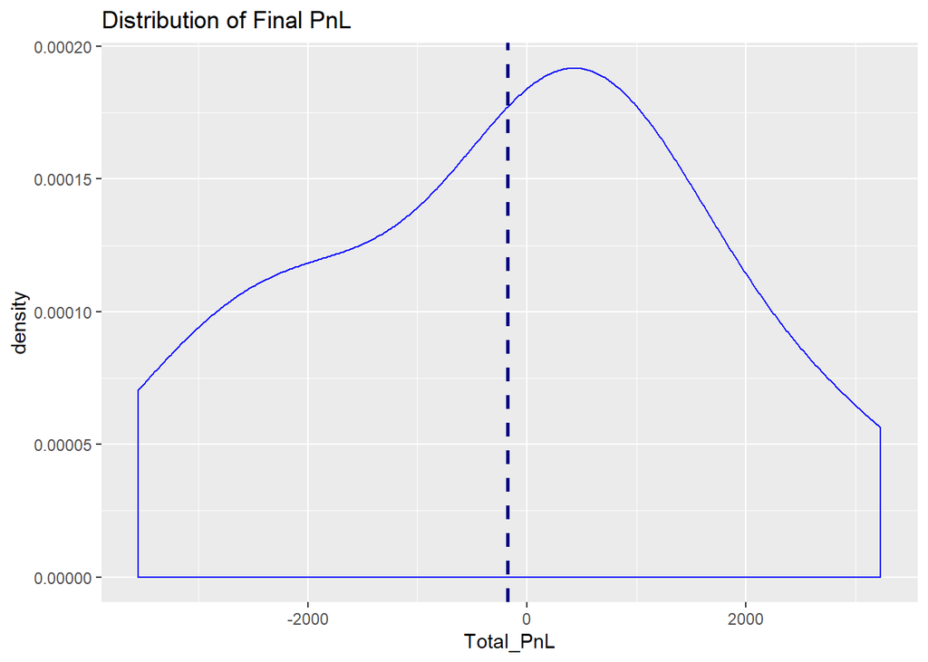

```r
ggplot(AMZNDFOutput, aes(x = Total_PnL)) +
  geom_density(color = "blue") +
  geom_vline(aes(xintercept=mean(AMZNDFOutput$Total_PnL)), color = "navy", linetype = "dashed", size = 1) +
  ggtitle("Distribution of Final PnL")
```

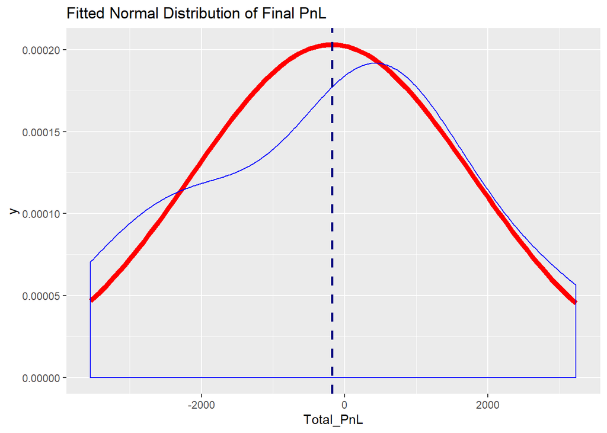

```r
ggplot(AMZNDFOutput, aes(x = Total_PnL)) +
  stat_function(fun = dnorm,
                args = list(mean = mean(AMZNDFOutput$Total_PnL), sd = stdev(AMZNDFOutput$Total_PnL)),
                color = "red",
                size = 2) +
  geom_density(color = "blue") +
  geom_vline(aes(xintercept=mean(AMZNDFOutput$Total_PnL)), color = "navy", linetype = "dashed", size = 1) +
  ggtitle("Fitted Normal Distribution of Final PnL")
```

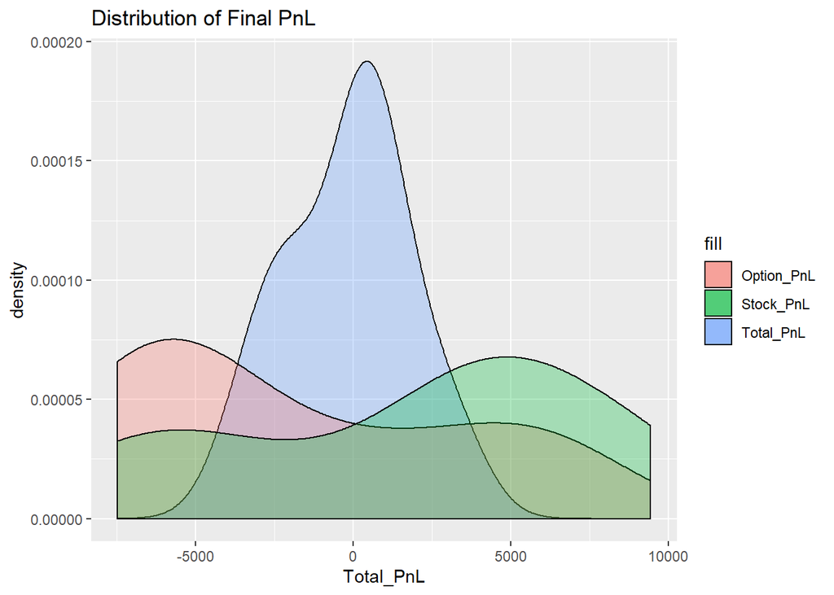

```r
ggplot(AMZNDFOutput) +
  geom_density(aes(Total_PnL, fill = "Total_PnL"), alpha = 0.3) +
  geom_density(aes(Option_PnL, fill = "Option_PnL"), alpha = 0.3) +
  geom_density(aes(Stock_PnL, fill = "Stock_PnL"), alpha = 0.3) +
  ggtitle("Distribution of Final PnL")
```

### 2. Distribution of Max Drawdown

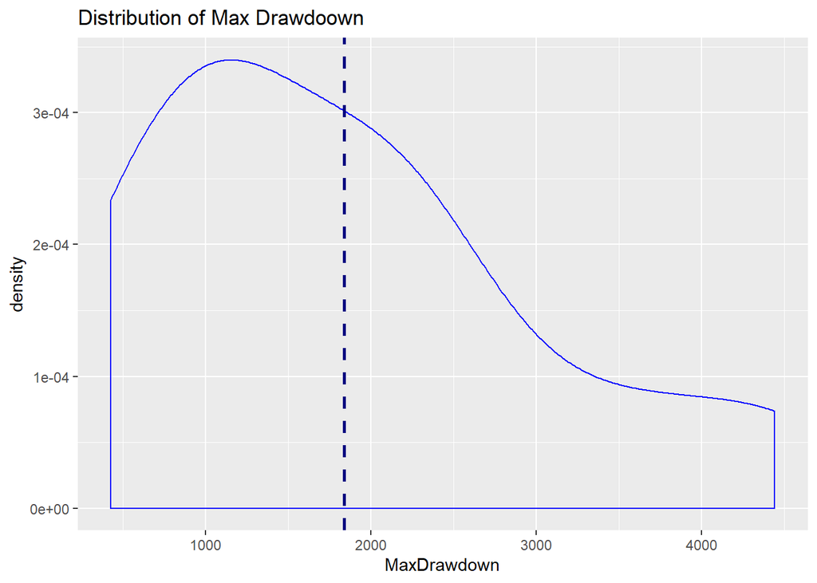

```r
ggplot(AMZNDFOutput, aes(x = MaxDrawdown)) +
  geom_density(color = "blue") +
  geom_vline(aes(xintercept=mean(AMZNDFOutput$MaxDrawdown)), color = "navy", linetype = "dashed", size = 1) +
  ggtitle("Distribution of Max Drawdoown")
```

### 3. Final PnL vs. Date

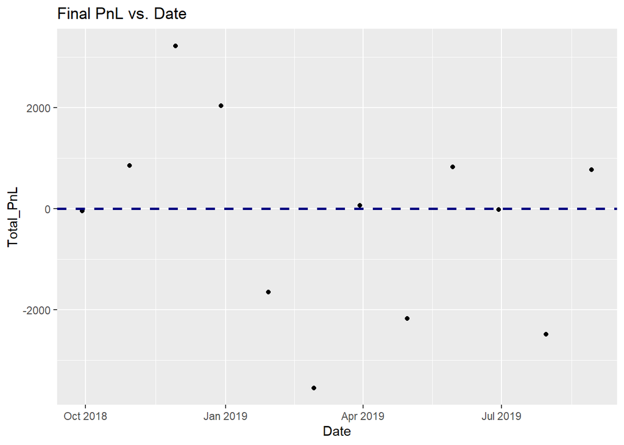

```r
ggplot(AMZNDFOutput) +
  geom_point(aes(y = Total_PnL, x = date+29)) +
  geom_hline(aes(yintercept=mean(AMZNDFOutput$SharpeRatio)), color = "navy", linetype = "dashed", size = 1) +
  ggtitle("Final PnL vs. Date") +
  xlab("Date")
```

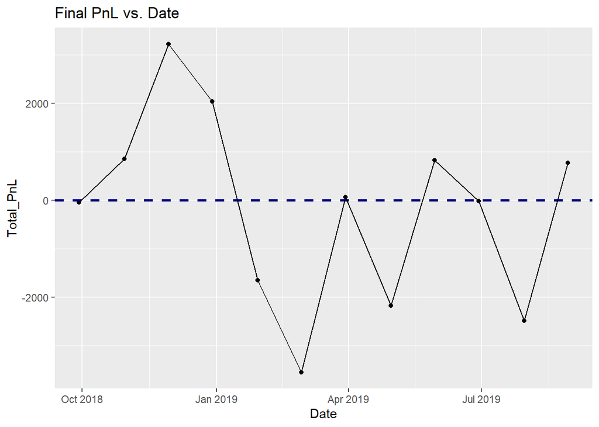

```r
ggplot(AMZNDFOutput) +
  geom_point(aes(y = Total_PnL, x = date+29)) +
  geom_hline(aes(yintercept=mean(AMZNDFOutput$SharpeRatio)), color = "navy", linetype = "dashed", size = 1) +
  geom_line(aes(y = Total_PnL, x = date+29)) +
  ggtitle("Final PnL vs. Date") +
  xlab("Date")
```

### 4. Distribution of Sharpe Ratio

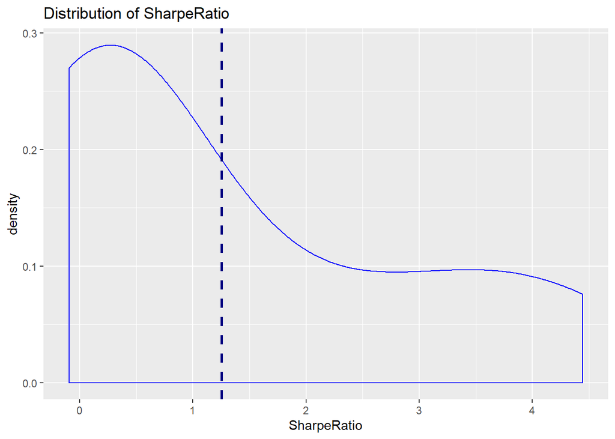

```r
ggplot(AMZNDFOutput, aes(x = SharpeRatio)) +
  geom_density(color = "blue") +
  geom_vline(aes(xintercept=mean(AMZNDFOutput$SharpeRatio)), color = "navy", linetype = "dashed", size = 1) +
  ggtitle("Distribution of SharpeRatio")
```

### 5. Implied Volatility vs Realized Volatility

```r
RealizedVol <- RealizedVol[-1]
ImpliedVol <- ImpliedVol[-1]
Dates <- as.Date(Dates[-1])
PNL <- AMZNDFOutput$Total_PnL
VolDF <- tibble(date = Dates) %>%
    mutate(Realized = RealizedVol) %>%
    mutate(Implied = ImpliedVol) %>%
    mutate(PnL = PNL) %>%
    mutate(RealizedminusImplied = Realized-Implied)
VolDF
```

```
## # A tibble: 12 x 5
##    date       Realized Implied     PnL RealizedminusImplied
##    <date>        <dbl>   <dbl>   <dbl>                <dbl>
##  1 2018-08-31     24.6    23.8   -41.7                0.834
##  2 2018-10-01     56.9    32.6   855.                24.3
##  3 2018-10-31     50.5    40.9  3228.                 9.61
##  4 2018-11-30     61.4    37.6  2040.                23.8
##  5 2018-12-31     35.8    48.4 -1647.               -12.6
##  6 2019-01-30     28.2    39.3 -3548.               -11.1
##  7 2019-03-01     23.7    23.8    65.2               -0.158
##  8 2019-04-01     14.4    29.3 -2177.               -14.9
##  9 2019-05-01     24.5    22.2   823.                 2.29
## 10 2019-05-31     26.0    29.3   -16.7               -3.26
## 11 2019-07-01     15.4    25.8 -2483.               -10.3
## 12 2019-07-31     27.0    24.9   772.                 2.09
```

From the table above, we can see that the P&L of each period generally have the same sign as (Realzied Volatility-Implied Volatility), which means when realized volatility is higher than implied volatility, P&L is positive. This finding is consistent with Q2.